# Data exploration

```python
import numpy as np
import pandas as pd
import matplotlib.pyplot as plt
import seaborn as sns
from pathlib import Path
import dask.dataframe as dd
from dask.distributed import Client, progress
import dask as d
```

## Create dask dataframe and preview

```python
in_csv = '/home/diego/Coding/code-challenge-2020/data_root/raw/wine_dataset.csv'

client = Client(n_workers=2, threads_per_worker=2, memory_limit='1GB')
```

```python
ddf = dd.read_csv(in_csv, blocksize=1e6)
ddf = ddf.set_index('Unnamed: 0')
ddf.head()
#ddf.dtypes
```

| Unnamed: 0 | country | description | designation | points | price | province | region_1 | region_2 | taster_name | taster_twitter_handle | title | variety | winery |
| --- | --- | --- | --- | --- | --- | --- | --- | --- | --- | --- | --- | --- | --- |
| 0 | Italy | Fragrances suggest hay, crushed tomato vine an... | Kirchleiten | 90 | 30.0 | Northeastern Italy | Alto Adige | NaN | Kerin O’Keefe | @kerinokeefe | Tiefenbrunner 2012 Kirchleiten Sauvignon (Alto... | Sauvignon | Tiefenbrunner |
| 1 | France | Packed with fruit and crisp acidity, this is a... | NaN | 87 | 22.0 | Loire Valley | Sancerre | NaN | Roger Voss | @vossroger | Bernard Reverdy et Fils 2014 Rosé (Sancerre) | Rosé | Bernard Reverdy et Fils |
| 2 | Italy | This easy, ruby-red wine displays fresh berry ... | NaN | 86 | NaN | Tuscany | Chianti Classico | NaN | NaN | NaN | Dievole 2009 Chianti Classico | Sangiovese | Dievole |
| 3 | US | Pretty in violet and rose petals this is a low... | Horseshoe Bend Vineyard | 92 | 50.0 | California | Russian River Valley | Sonoma | Virginie Boone | @vboone | Davis Family 2012 Horseshoe Bend Vineyard Pino... | Pinot Noir | Davis Family |
| 4 | US | This golden wine confounds in a mix of wet sto... | Dutton Ranch | 93 | 38.0 | California | Russian River Valley | Sonoma | Virginie Boone | @vboone | Dutton-Goldfield 2013 Dutton Ranch Chardonnay ... | Chardonnay | Dutton-Goldfield |

```python
ddf.describe(include="all").compute()
```

|  | country | description | designation | points | price | province | region_1 | region_2 | taster_name | taster_twitter_handle | title | variety | winery |
| --- | --- | --- | --- | --- | --- | --- | --- | --- | --- | --- | --- | --- | --- |
| unique | 37 | 9942 | 5381 | NaN | NaN | 248 | 724 | 17 | 18 | 14 | 9930 | 333 | 5460 |
| count | 9994 | 10000 | 7171 | 10000.000000 | 9323.000000 | 9994 | 8336 | 3853 | 8015 | 7644 | 10000 | 10000 | 10000 |
| top | US | This fresh, juicy wine is full of red fruits a... | Reserve | NaN | NaN | California | Napa Valley | Central Coast | Roger Voss | @vossroger | Ca' del Bosco NV Cuvée Prestige Sparkling (Fra... | Pinot Noir | Chateau Ste. Michelle |
| freq | 4153 | 2 | 165 | NaN | NaN | 2753 | 350 | 847 | 1956 | 1956 | 3 | 1015 | 19 |
| mean | NaN | NaN | NaN | 88.460000 | 35.447603 | NaN | NaN | NaN | NaN | NaN | NaN | NaN | NaN |
| std | NaN | NaN | NaN | 3.030003 | 40.898626 | NaN | NaN | NaN | NaN | NaN | NaN | NaN | NaN |
| min | NaN | NaN | NaN | 80.000000 | 5.000000 | NaN | NaN | NaN | NaN | NaN | NaN | NaN | NaN |
| 25% | NaN | NaN | NaN | 87.000000 | 17.000000 | NaN | NaN | NaN | NaN | NaN | NaN | NaN | NaN |
| 50% | NaN | NaN | NaN | 88.000000 | 25.000000 | NaN | NaN | NaN | NaN | NaN | NaN | NaN | NaN |
| 75% | NaN | NaN | NaN | 91.000000 | 42.750000 | NaN | NaN | NaN | NaN | NaN | NaN | NaN | NaN |
| max | NaN | NaN | NaN | 100.000000 | 1300.000000 | NaN | NaN | NaN | NaN | NaN | NaN | NaN | NaN |

```
Wine points mean: 88.46 ± 3.0300029854455888
Wine price mean: 35.4476027029926 ± 40.898626059975335
```

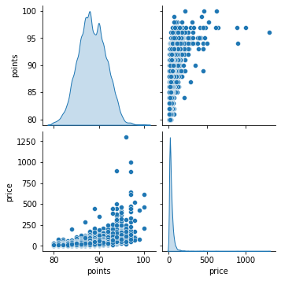

```python
# See correltion of numerical features and number of outliers
cols = ['points', 'price']
print(f"Wine points mean: {ddf['points'].mean().compute()} ± {ddf['points'].std().compute()}")
print(f"Wine price mean: {ddf['price'].mean().compute()} ± {ddf['price'].std().compute()}")
# sns.pairplot(ddf[cols].compute(), kind='reg', diag_kind='kde')
sns.pairplot(ddf[cols].compute(), diag_kind='kde')
```

We can see that the 'points' feature follows a more or less normal distribution. The price however has some big pretty big outliers.

```
Average wines per country: 270.1081081081081 ± 755.86189890099
```

```
[Text(0.5, 1.0, 'Number of wines per country')]
```

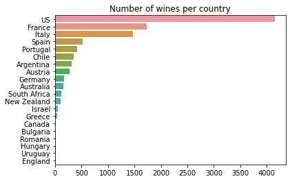

```python
wines_per_country = ddf.country.value_counts().compute()
wines_per_country = wines_per_country.sort_values(ascending=False)
print(f"Average wines per country: {wines_per_country.mean()} ± {wines_per_country.std()}")
wines_per_country = wines_per_country.iloc[0:20]
g = sns.barplot(y=wines_per_country.index, x=wines_per_country.values)
g.set(title='Number of wines per country')
```

Moreover, we can also see that the dataset is quite unbalanced. When we look at the number of wines (datapoints) grouped by country, we see that most of the wines are concentrated in a handful of countries. We might need some sampling in order to deal with an unbalanced dataset.

## Preprocess dataset. Dealing with NaN values

```
Original size: 10000
Number of rows with 0 NaN values: 1683
Ratio of NaNs in each column:

country                  0.0006
description              0.0000
designation              0.2829
points                   0.0000
price                    0.0677
province                 0.0006
region_1                 0.1664
region_2                 0.6147
taster_name              0.1985
taster_twitter_handle    0.2356
title                    0.0000
variety                  0.0000
winery                   0.0000
dtype: float64
```

```
[Text(0.5, 1.0, 'Number of NaN per category')]
```

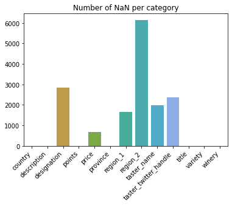

```python
# There is very few complete rows
print("Original size: {}".format(len(ddf), len(ddf.columns)))
print("Number of rows with 0 NaN values: {}".format(len(ddf.dropna())))
df2 = ddf.isna().sum().compute()
print("Ratio of NaNs in each column:\n\n{}".format(df2/len(ddf)))

g = sns.barplot(x=df2.index, y=df2)
plt.setp(g.get_xticklabels(), rotation=45, ha='right')
g.set(title="Number of NaN per category")
```

```python
print("Number of different designations: {}".format(len(ddf.groupby(['designation']).size())))
```

```
Number of different designations: 5381
```

Region_2 column should be dropped directly, there is too little realible data. Designation column has too many NaN values and too many unique values. Better to drop column. Finally, the description column would need some NLP processing so we will drop it for now (possible model improvement if using some kind of NLP on this col e.g. bag of words).

### Dealing with NaN values in categorical columns

We can see that if the information about a country is missing, then the province and region values are missing as well. Thus, is not possible to fill country values. We will use an 'Unknown' type to fill in missing values.

```python
# If country is missing, province, and regions are missing as well.
print(len(ddf.loc[(ddf['country'].isnull()) & (~ddf['province'].isnull())]))
# Cant guess province based on country
print(len(ddf.loc[(ddf['province'].isnull()) & (~ddf['country'].isnull())]))
ddf['country'] = ddf['country'].fillna('Unknown')
ddf['province'] = ddf['province'].fillna('Unknown')

# The custom aggregate mode function works. But very few cases where it is useful.

def chunk(s):
    return s.value_counts()


def agg(s):
    return s.apply(lambda s: s.groupby(level=-1).sum())


def finalize(s):
    level = list(range(s.index.nlevels - 1))
    return (
        s.groupby(level=level)
        .apply(lambda s: s.reset_index(level=level, drop=True).idxmax())
    )


mode = dd.Aggregation('mode', chunk, agg, finalize)
most_common_region = (ddf.groupby(['province'])
                      .agg({'region_1': mode}).compute())


ddf['region_1'] = ddf.apply(lambda x: most_common_region.loc[x.province, 'region_1']
                            if x.province in most_common_region['region_1'].index else 'Unknown',
                            meta=(None, 'object'), axis=1).where(ddf['region_1'].isna(), ddf['region_1'])
```

```
0
0
```

We try to see if we can fill some of the NaN values of region_1 with information from region_2 (This is possible because region_2 contains region_1). For example using most common value for a specific region_2 to fill region_1 missing value. However there is 100% overlap of missing values. Maybe in bigger dataset but for now is not an option.

However we can try to fill missing values using the 'province' column. Most common value for each province will be used. However since there is so many NaN values in region_1, lots of provinces don't have a most frequent region. This makes it so only a few rows are filled with most frequent region in province, rest are labeled as Unknown.

```python
print(len(ddf[ddf['taster_name'].isnull()  & ~ddf['taster_twitter_handle'].isnull()].compute()))
ddf['taster_name'] = ddf['taster_name'].fillna('Unknown')
```

```
0
```

We try to merge twitter handle and taster name since they are equivalent. However, there is no additional information in taster_twitter_handle column. It is possible that in the bigger dataset this merge can be done more effectively. But for now we will drop the 'taster_twitter_handle' column since it has more NaN values.

```python
len(ddf['title'].unique())
```

```
9930
```

We see that the title column has mostly unique values, which make this variable of little value. We will drop it for now.

### Filling price data

We try to fill price values first using the average price in the province. If that can't be obtained, we used the global average price.

```python
mean_prices = ddf.groupby(['province'])['price'].mean().compute()
global_mean = ddf['price'].mean().compute()
mean_prices = mean_prices.fillna(global_mean)
ddf['price']=ddf.apply(lambda x: mean_prices[x['province']], axis=1, meta=('x', 'f8')).where(ddf['price'].isna(),ddf['price'])
```

```python
df2 = ddf.drop(['description', 'designation','region_2', 'taster_twitter_handle', 'title'], axis=1)
print("Ratio of NaNs in each column:\n\n{}".format(df2.isna().sum().compute()/len(ddf)))
df2.head()
```

```
Ratio of NaNs in each column:

country        0.0
points         0.0
price          0.0
province       0.0
region_1       0.0
taster_name    0.0
variety        0.0
winery         0.0
dtype: float64
```

| Unnamed: 0 | country | points | price | province | region_1 | taster_name | variety | winery |
| --- | --- | --- | --- | --- | --- | --- | --- | --- |
| 0 | Italy | 90 | 30.00000 | Northeastern Italy | Alto Adige | Kerin O’Keefe | Sauvignon | Tiefenbrunner |
| 1 | France | 87 | 22.00000 | Loire Valley | Sancerre | Roger Voss | Rosé | Bernard Reverdy et Fils |
| 2 | Italy | 86 | 48.97995 | Tuscany | Chianti Classico | Unknown | Sangiovese | Dievole |
| 3 | US | 92 | 50.00000 | California | Russian River Valley | Virginie Boone | Pinot Noir | Davis Family |
| 4 | US | 93 | 38.00000 | California | Russian River Valley | Virginie Boone | Chardonnay | Dutton-Goldfield |